# Prosper Loan Analysis

# Bivariate Plots

Lets start off simple and see if current deliquincies has any bearing on whether or not the loan was defaulted

```
## # A tibble: 1 x 1
##       n
##   <int>
## 1  5018
```

```
## # A tibble: 1 x 1
##       n
##   <int>
## 1 23498
```

Here we see that 40% of people of with a current delinquincy have defaulted on their loan. Over 99% of people with a past due have a current delinquincy

```
##           n
## 1 0.4065365
```

```
##           n
## 1 0.9946368
```

Next we will try to answer the question posed in our first section. Does a higher interest rate lead to more delinquencies?

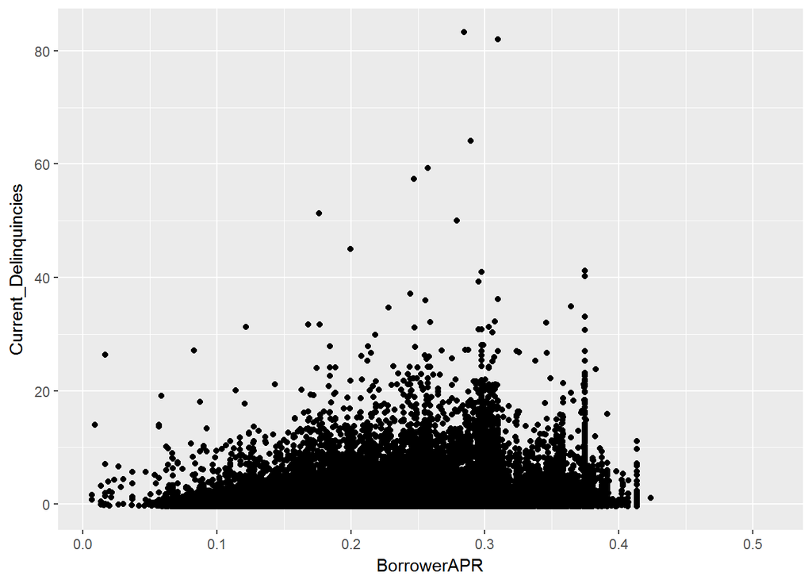

This is an interesting find, lets keep going.

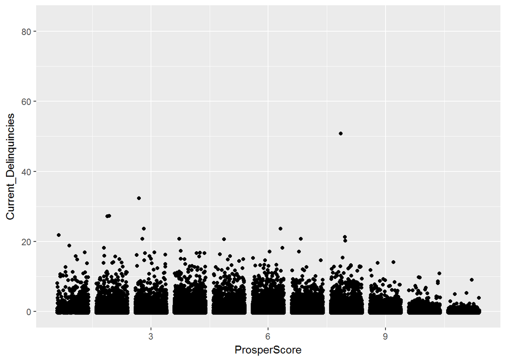

Another question we asked was if Listing Category made a difference in delinquincies or not. This does not seem to be the case.

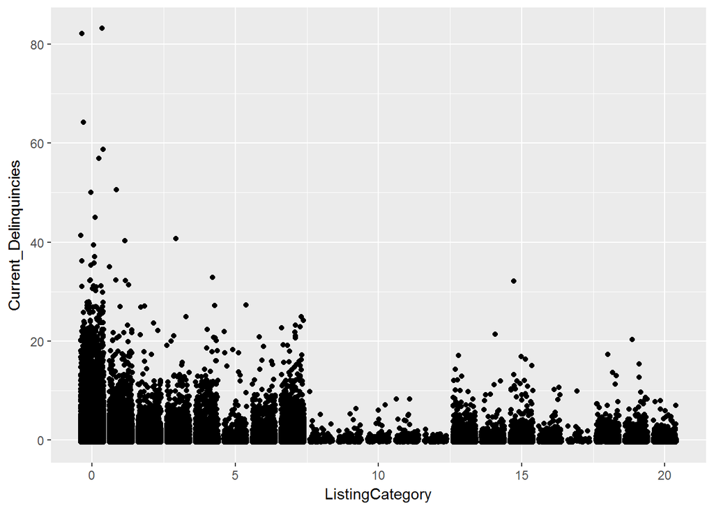

Credit Score did show a trend however. The trend shows that people with higher credit scores do tend to have less delinquincies.

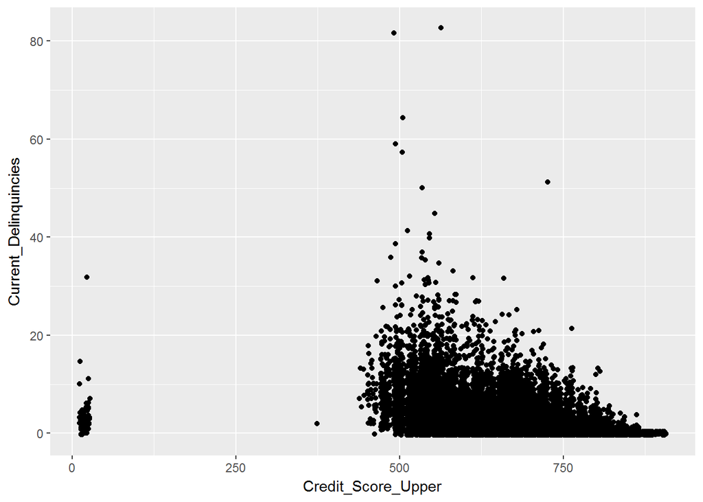